# Milestone Report

Zainil Jessani

June 12, 2016

## SYNOPSIS

The goal of the Capstone Data Science Project is to create a predictive text application using data obtained from SwiftKey. The following Milestone Report outlines the steps taken to download, sample, and explore the data provided. At the end an overview of the predictive algorithm will be provided.

## DOWNLOAD

The data for this Capstone Project was obtained from SwiftKey via the Coursera website.

```r
data.source <- "https://d396qusza40orc.cloudfront.net/dsscapstone/dataset/Coursera-Swiftkey.zip"

data.destination <- "Coursera-Swiftkey.zip"
download.file(data.source, data.destination) ## download
unzip(data.destination)  ## extraction
```

## DESCRIPTION

There are 4 languages provided; Russian, Finnish, German, and English. Using the English data the following is a breakdown of the files (done in Mac OS X terminal):

Files: “en_US.blogs.txt” | “en_US.twitter.txt” | “en_US.news.txt”  
Size: 210 MB | 167 MB | 205 MB  
Lines: 899,288 | 2,360,148 | 1,010,242  
Words: 37,334,690 | 30,374,206 | 34,372,720

## SAMPLE

Given the large size of the data files a random sample was taken from each of the 3 files to give a approximation for the purpose of exploratory analysis and fine tuning methods for data cleaning.

```r
sample.data <- function(input, output, probability) { ##sample function
    conn <- file(input, "r")
    set.seed(967)
    all.sample <- readLines(conn,
                            encoding = "UTF-8",
                            skipNul = TRUE)
    subset.input <- all.sample[rbinom(n = length(all.sample),
                                      size = 1,
                                      prob = probability) == 1]
    close(conn)

    conn.2 <- file(output, "w")
    writeLines(subset.input, conn.2)
    close(conn.2)
}

sample.data("en_US.blogs.txt",
            "sample/sample.en_US.blogs.txt",
            0.081) ##blogs sample
sample.data("en_US.news.txt",
            "sample/sample.en_US.news.txt",
            0.061) ##news sample
sample.data("en_US.twitter.txt",
            "sample/sample.en_US.twitter.txt",
            0.00698) ##twitter sample
```

## CORPUS

The next step in the analysis was to create a Corpus (a structured set of texts) to store the sampled text files that were created above.

```r
library(tm)
docs <- DirSource("sample/") ##source object
corpus <- VCorpus(docs)  ##stored in memory
```

## CLEANING

The first step in cleaning the Corpus was to load a profanity text in an effort to rid the Corpus of profane language. This was followed up by using the “tm” package to rid the corpus of punctuation, numbers, profanity, additional whitespace, and convert all characters to lowercase.

```r
conn.3 <- file("profanity.txt",
               open = "rb") ## load profanity words
profanity <- readLines(conn.3,
                       encoding = "UTF-8",
                       skipNul = TRUE)
close(conn.3)

spacer <- content_transformer(function(x, pattern)
    {return (gsub(pattern, " ", x))}) ##replace special chars with " "

corpus <- tm_map(corpus, spacer, ":") ## remove ":"
corpus <- tm_map(corpus, spacer, "/") ## remove "/"
corpus <- tm_map(corpus, spacer, "@") ## remove "@"
corpus <- tm_map(corpus, spacer, "-") ## remove "-"
corpus <- tm_map(corpus, spacer, "#") ## remove "#"
corpus <- tm_map(corpus, content_transformer(tolower)) ## lowercase
corpus <- tm_map(corpus, removeWords, profanity) ##profanity
corpus <- tm_map(corpus, removePunctuation) ## punctuation
corpus <- tm_map(corpus, removeNumbers) ## numbers
corpus <- tm_map(corpus, stripWhitespace) ## whitespace
```

## ANALYSIS

The analysis of the cleaned Corpus was done by first creating a Term Document Matrix (TDM) a matrix that lists all occurances of words in the Corpus. Since the Corpus has been tranformed into a mathematical object we can now use math operations to sort the words by frequency. I do this for individual words, and phrases (known as n-grams) that are 2, 3, or 4 words long (2-gram, 3-gram, 4-gram).

```r
## 1-gram
tdm <- TermDocumentMatrix(corpus) ## tdm
tdm <- removeSparseTerms(tdm, 0.8) ## sparse
freq <- colSums(t(as.matrix(tdm))) ## word frequency
ord <- order(freq, decreasing = TRUE)  ## order by decreasing
freq <- freq[head(ord, n = 100)] ## top 100 words
df <- data.frame(word =names(freq), freq = freq) ## data frame
rm(tdm, freq, ord)

## 2-gram
bitokenizer <- function(x)
    unlist(lapply(ngrams(words(x),2),
                  paste,
                  collapse=" "),
           use.names = FALSE)
bigram <- TermDocumentMatrix(corpus,
                             control =
                                 list(tokenize = bitokenizer))
bigram <- removeSparseTerms(bigram, 0.8)
bi.freq <- colSums(t(as.matrix(bigram)))
bi.ord <- order(bi.freq,
                decreasing = TRUE)
bi.freq <- bi.freq[head(bi.ord, n =100)]
bi.df <- data.frame(word = names(bi.freq),
                    freq = bi.freq)
rm(bitokenizer, bigram, bi.freq, bi.ord)

## 3-gram
tritokenizer <- function(x)
    unlist(lapply(ngrams(words(x),3),
                  paste,
                  collapse=" "),
           use.names = FALSE)
trigram <- TermDocumentMatrix(corpus,
                              control =
                                  list(tokenize = tritokenizer))
trigram <- removeSparseTerms(trigram, 0.8)
tri.freq <- colSums(t(as.matrix(trigram)))
tri.ord <- order(tri.freq,
                 decreasing = TRUE)
tri.freq <- tri.freq[head(tri.ord, n =100)]
tri.df <- data.frame(word = names(tri.freq),
                     freq = tri.freq)
rm(tritokenizer, trigram, tri.freq, tri.ord)

## 4-gram
quadtokenizer <- function(x)
    unlist(lapply(ngrams(words(x),4),
                  paste,
                  collapse=" "),
           use.names = FALSE)
quadgram <- TermDocumentMatrix(corpus,
                               control =
                                   list(tokenize = quadtokenizer))
quadgram <- removeSparseTerms(quadgram, 0.8)
quad.freq <- colSums(t(as.matrix(quadgram)))
quad.ord <- order(quad.freq,
                  decreasing = TRUE)
quad.freq <- quad.freq[head(quad.ord, n =100)]
quad.df <- data.frame(word = names(quad.freq),
                      freq = quad.freq)
rm(quadtokenizer, quadgram, quad.freq, quad.ord)
```

## VISUALIZATION

The following plots illustrate the analysis done above in R.

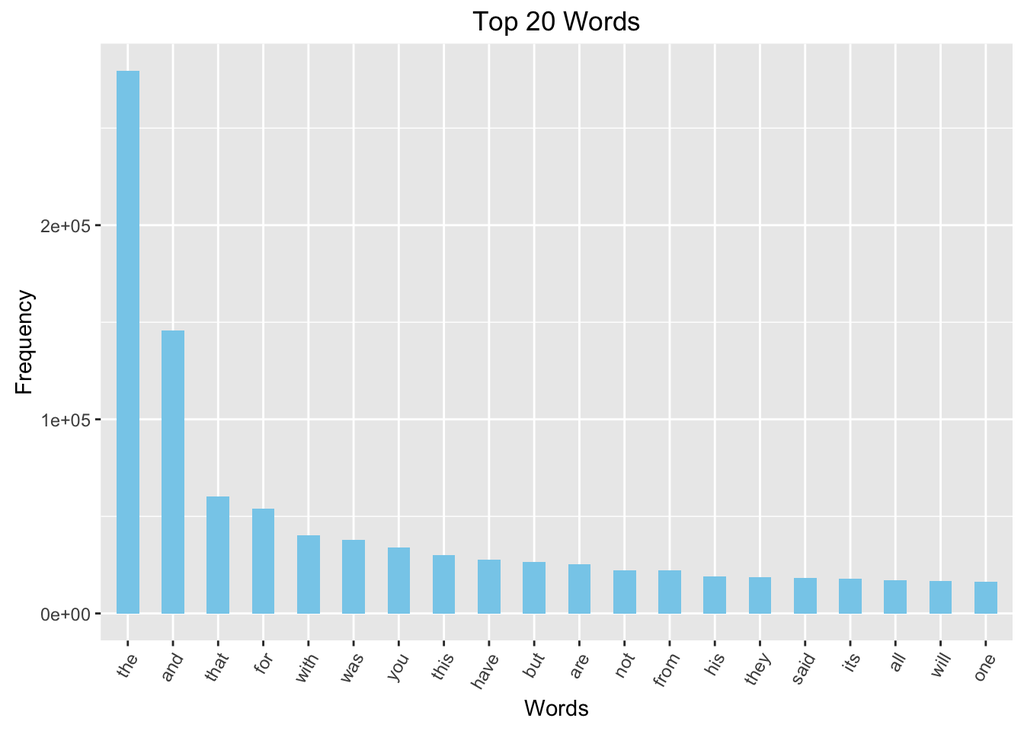

```r
library(ggplot2)

frequency.plot <- function(data, heading, col) {
    ggplot(data[1:20, ], aes(x = seq(1:20), y = freq)) +
        geom_bar(stat = "identity", fill = col, width = 0.5) +
        coord_cartesian(xlim = c(1, 20)) +
        labs(title = heading) +
        xlab("Words") +
        ylab("Frequency") +
        scale_x_discrete(breaks = seq(1, 20, by = 1), labels = data$word[1:20]) +
        theme(axis.text.x = element_text(angle = 60, hjust = 1))
}

frequency.plot(df, "Top 20 Words", "skyblue")
```

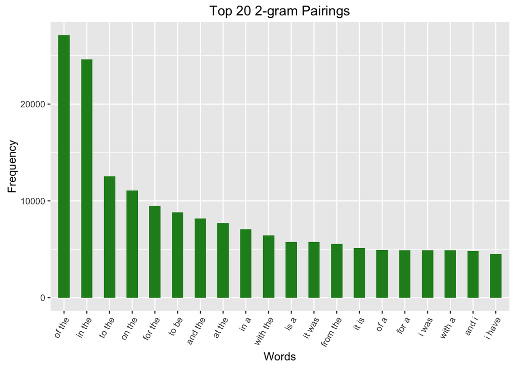

```r
frequency.plot(bi.df, "Top 20 2-gram Pairings", "forestgreen")
```

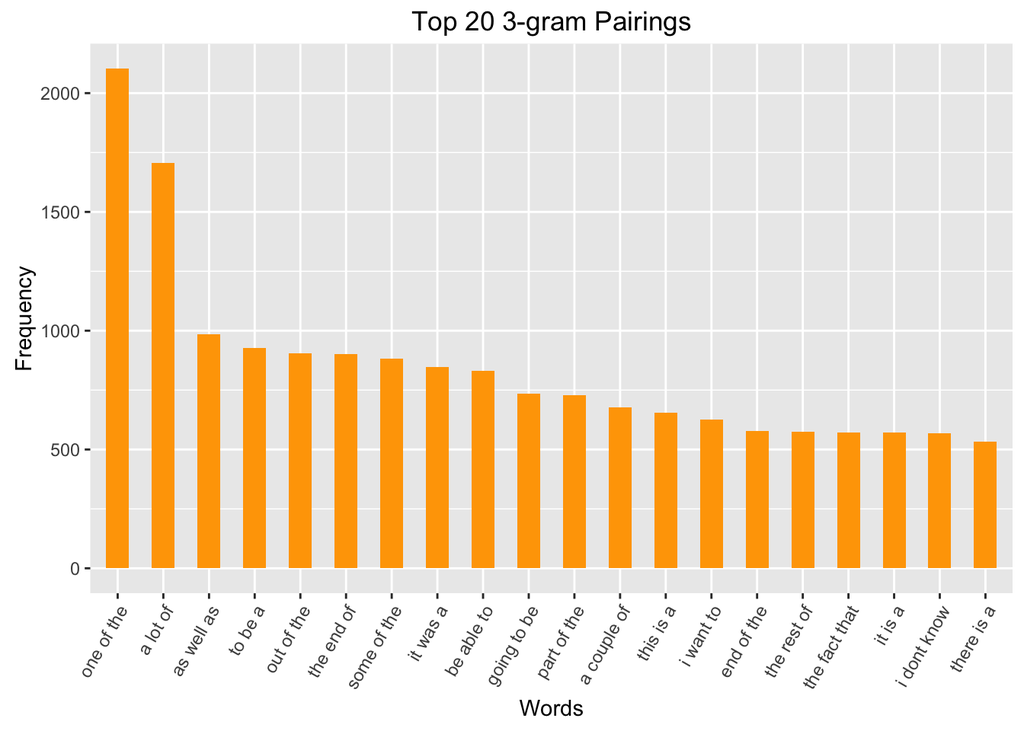

```r
frequency.plot(tri.df, "Top 20 3-gram Pairings", "orange")
```

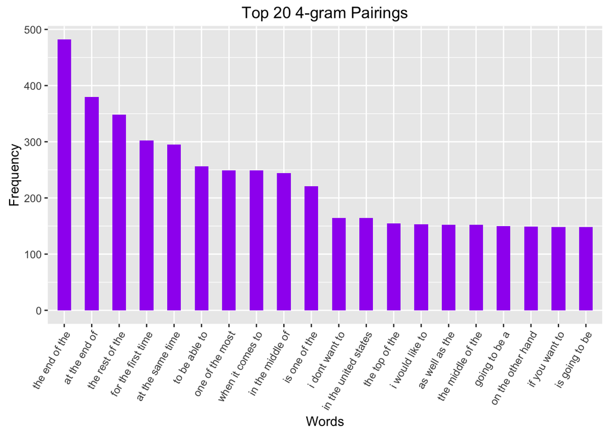

```r
frequency.plot(quad.df, "Top 20 4-gram Pairings", "purple")
```

## FUTURE

The next step in the design of the text prediction algorithm will be to:

1. Work with a larger trainign set. The words/phrases that are rare are important because they are often descriptive in a way that stop words such as (a, as , then, can, me, etc) are not.
2. Clean the data as above.
3. Algorithm: I will try using a lookup algorithm where a user input in the Shiny App is analysed with the TDM in order to find the 3 most likely words that would succeed the user input. For example, “Where in the” might be the user input, based on this the algorithm would look in the TDM and find the most common 4-grams that correspond with the input and recommend a word to add to the end.